# Burn-In

Nick O’Brien

23/07/2020

## Introduction

I’ve been having some problems setting up the burn in for my simulations. The premise is that at mutation-drift equilibrium, the population’s mean heterozygosity should be relatively stable, as predicted by population genetics theory. The time to burn-in should be proportional to 4 times the population size, and the predicted heterozygosity is equal to 4Nu. This is assuming completely neutral drift.

However, I’ve found I have been approaching the problem from the wrong angle: I need to be looking at the cyclical nature of heterozygosity as would be expected under mutation-drift balance (or mutation-drift-selection balance). Although on average over many seeds, you would expect the mean population heterozygosity to reach 4Nu, for any given seed, it is unlikely to stay at that point over time exactly: rather, mutations accumulate to push heterozygosity higher, and then drift results in fixation or loss, bringing the heterozygosity lower again. This results in a cycle (almost like a sine or cosine wave) that have amplitude and frequency proportional to population size, mutation rate, and other parameters - recombination, deleterious mutation, etc.

Here, I examine this cyclical action with several population sizes in order to better understand the signature of a population in mutation-drift balance, and choose appropriate points to assume a population is burnt in (given their population size).

In all of these models, recombination rates stay constant: rwide = 1.346e-5, and rregion = 1e-8 (not quite, but close to complete linkage between chromosomes).

To see this cyclical nature, we can take an autocorrelation plot, or a figure of the population mean heterozygosity over time. Here is an example of population size = 1000:

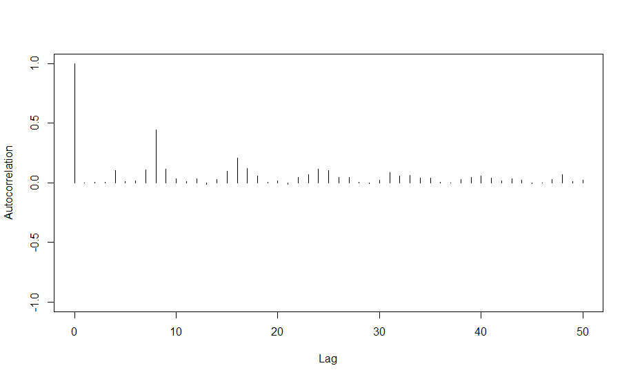

Population autocorrelation: Ne - 1000

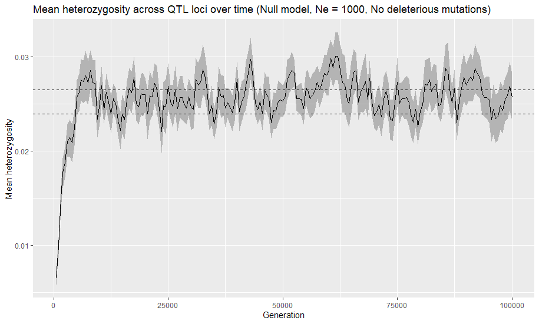

Population mean heterozygosity: Ne - 1000

Each ‘lag’ in the autocorrelation graph represents 500 generations. The dotted lines are 5% bounds of the expected heterozygosity under equilibrium (4Nu, where N = 1000, and u = 6.3e-6). As you can see, there is a cycle of autocorrelation spikes that appear every so often, however their amplitude gets smaller over time (as you get further away from the initial time point). This is a signature of mutation-drift equilibrium. The two dotted lines in the means figure represent 5% either side of the expected 4Nu value of heterozygosity at equilibrium. If across all seeds and all time points we got the mean of this data, we would find that we do get around that value, however the wave behaviour of heterozygosity at equilibrium over time does not allow that at all time points (and due to the stochasticity of drift, not at all seeds). In fact, this mean (after 20,000 generations, or well after that initial climb to equilibrium from the empty state) does fall within there, at 0.0259, very close to the prediction of 0.0252 (4Nu = 4 * 1000 * 6.3e-6).

## Null model

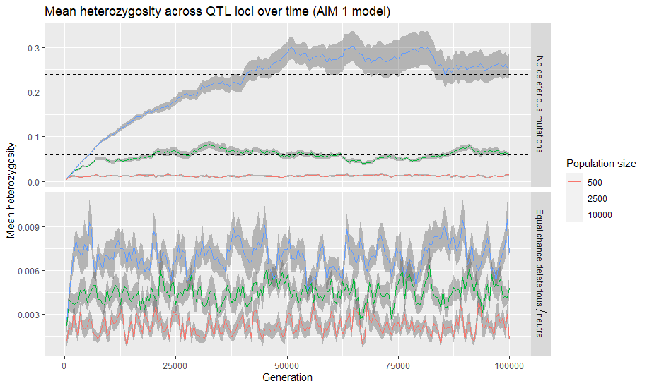

## Independent Assortment model

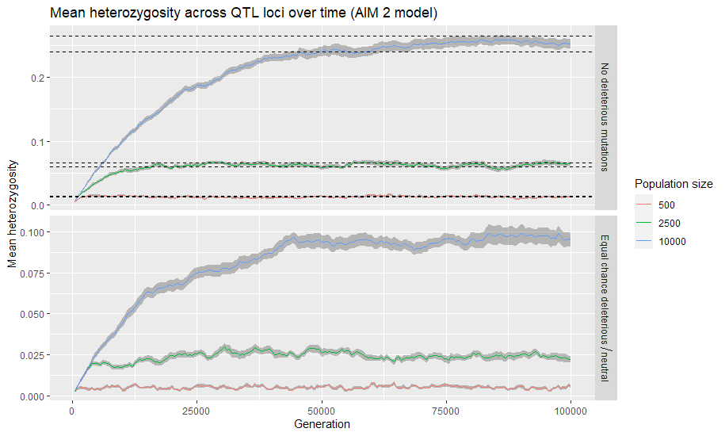

Strange change of trends: by randomising the sizes of chromosomes (via where the end points are), we get considerably less variation around the mean, much less amplitude of the wave of mutation-drift balance. My first thoughts of the reason for this are in my null model, where chromosome positions are fixed, there is a much greater chance for mutations to be spread unevenly within those chromosomes - almost always, some chromosomes will contain more loci than others. So the individual loci vary quite a lot in how linked they are, and that affects the rate at which they are fixed or lost together, altering heterozygosity according to this linkage. In this aim, because the end points are generated randomly (based on 10 loci chosen at random), there is a higher chance of the distance between loci being considerably further apart, so there is a lesser effect of linkage between loci, so they are indeed more independent and have smaller individual effects. I expect with more loci added (there are 100 in this model), the lines would become smoother with smaller CIs, and vice versa for fewer loci.

Also, probably due to an increased ability to get rid of deleterious mutations linked to QTLs, the mean heterozygosity is not reduced by as much as in AIM 1.

## Ne = 500

Below are figures of the same data, but only for Ne = 500:

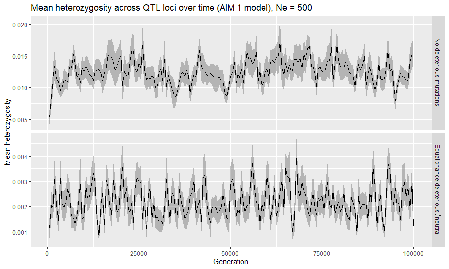

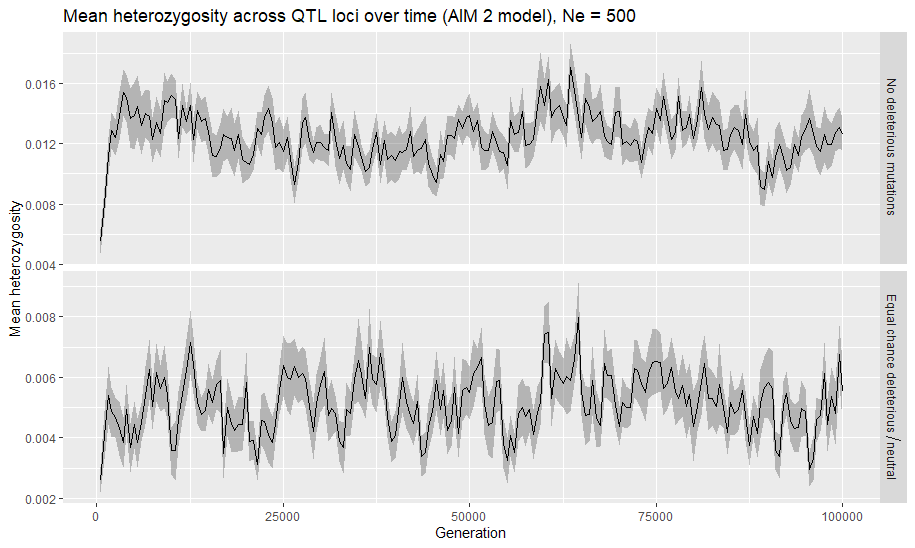

Deleterious mutation has some effect on global heterozygosity, with the amplitude becoming greater and the frequency becoming shorter. Especially in the aim 1 model, in aim 2 the effects are somewhat mitigated.

## Heterozygosity across the genome

The above figures show heterozygosity at only QTL loci - because these mutations are comparatively rare, each has a large effect on heterozygosity, resulting in a lot of variation between and within runs. When we plot heterozygosity of all sites across the genome, the trend is the same, but the variation is considerably different:

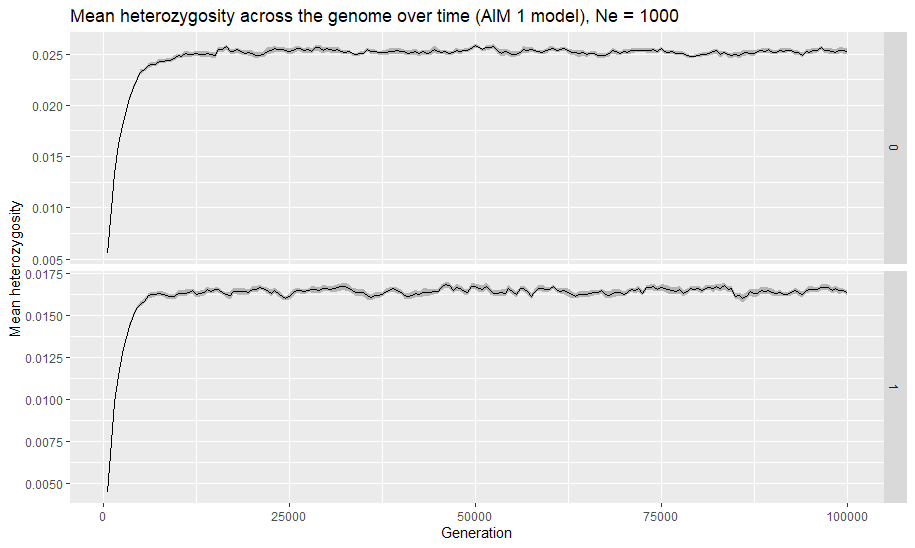

Here, deleterious mutations have a considerably smaller effect, likely due to the large number of neutral mutations: in the previous graphs, deleterious mutations far outnumbered the sites at which heterozygosity was calculated, swamping variation. Here, all mutation types are counted (including deleterious), so although deleterious mutations reduce variability, they aren’t swamping all others, so the effect is smaller. This can be extrapolated to further expectations: higher amounts of deleterious mutations will disproportionately affect heterozygosity at QTLs compared to neutral sites simply because they are more likely to be swamped. So, variability in trait values will fall a lot, even if the variability at neutral sites is not affected as much.